# 20212_M2_875_PEC1_Enunciado (1)

[figure not shown]

M2.875 · Deep Learning · PEC1

2021-2 · Máster universitario en Ciencia de datos (Data science)

Estudios de Informática, Multimedia y Telecomunicación

# PEC 1: Redes neuronales artificiales

En esta práctica implementaremos redes neuronales artificiales para resolver problemas de:

- Clasificación
- Regresión

**Importante: La entrega debe hacerse en formato notebook y en formato html donde se vea el código y los resultados y comentarios de cada ejercicio. Para exportar el notebook a html puede hacerse desde el menú File $\to$ Download as $\to$ HTML.**

**Victor H. Ayala Sánchez**

## 0. Contexto y carga de librerías

El siguiente código carga los paquetes necesarios para la práctica y lee el fichero de datos que usaremos.

Los datos contienen información sobre coches de segunda mano, sus características y el precio de re-venta en euros. En un primer ejercicio diseñaremos un modelo que nos permita clasificar los coches en tres grupos según su gama de precio. En el segundo ejercicio diseñaremos un modelo de regresión para predecir el precio de re-venta.

```python
import pandas as pd
import numpy as np

import matplotlib.pyplot as plt
import seaborn as sns
import timeit

import keras
from keras.models import Sequential, Model
from keras.layers import Dense
from tensorflow.keras.optimizers import Adam, SGD, Adadelta, Adagrad

from sklearn.model_selection import train_test_split
from sklearn.metrics import confusion_matrix, mean_squared_error, classification_report
from sklearn.preprocessing import OneHotEncoder, StandardScaler
```

```python
##To read directly from Drive in Google Colab use:
from google.colab import drive
drive.mount('/content/drive')
#input path: "./drive/MyDrive/CarPricesData.pkl"

##To read in Kaggle, upload file in Kaggle
##input path: "/kaggle/input/botnetdl/botnet_dataset_DL.csv"
```

```python
url = '/content/drive/MyDrive/UOC-DataScience/DL_Operativa/dataset.csv'
df = pd.read_csv(url)
df.head()
```

|  | months_old | km | fuel_type | horsepower | metcolor | automatic | size_engine | doors_num | weight | price |
| --- | --- | --- | --- | --- | --- | --- | --- | --- | --- | --- |
| 0 | 73 | 97494 | Petrol | 110 | 1 | 0 | 1600 | 5 | 1085 | 10950 |
| 1 | 48 | 89049 | Petrol | 97 | 1 | 0 | 1400 | 5 | 1060 | 13500 |
| 2 | 40 | 161000 | Diesel | 69 | 1 | 0 | 1900 | 3 | 1105 | 13950 |
| 3 | 37 | 38812 | Petrol | 97 | 0 | 0 | 1400 | 3 | 1025 | 13450 |
| 4 | 55 | 33230 | Petrol | 110 | 0 | 0 | 1600 | 3 | 1050 | 13500 |

```python
pd.options.display.max_rows = 999
```

```python
#df = pd.read_csv("dataset.csv") #change path if needed
```

```python
#df.sample(5)
```

[output not shown]

## 1. Exploración (1 punto)

En primer lugar exploraremos el conjunto de datos.

**Ejercicio (1 punto):** Explora los datos:

- Indica el tamaño del dataset y el número de variables categóricas y continuas del conjunto de datos
- Grafica las distribuciones de las variables categóricas y de las continuas
- Genera una tabla de correlaciones de todas las variables usando la librería `seaborn`, mostrando en cada casilla el valor de la correlación
- Genera una tabla (usando la librería `seaborn`) que muestre únicamente las correlaciones entre el precio y el resto de variables, ordenada de mayor a menor según los valores de correlación
- Comenta los resultados de la exploración de datos
- **Variables**

```python
#Dataset size
print("Tamaño del dataset: ")
print("--------------------")
print("Número total de registros: {}".format(df.shape[0]))
print("--------------------")
print("Número total de columnas: {}".format(df.shape[1]))
```

```
Tamaño del dataset:
--------------------
Número total de registros: 1436
--------------------
Número total de columnas: 10
```

```python
df.info()
```

```
<class 'pandas.core.frame.DataFrame'>
RangeIndex: 1436 entries, 0 to 1435
Data columns (total 10 columns):
 #   Column       Non-Null Count  Dtype
---  ------       --------------  -----
 0   months_old   1436 non-null   int64
 1   km           1436 non-null   int64
 2   fuel_type    1436 non-null   object
 3   horsepower   1436 non-null   int64
 4   metcolor     1436 non-null   int64
 5   automatic    1436 non-null   int64
 6   size_engine  1436 non-null   int64
 7   doors_num    1436 non-null   int64
 8   weight       1436 non-null   int64
 9   price        1436 non-null   int64
dtypes: int64(9), object(1)
memory usage: 112.3+ KB
```

Revisamos las posibles variables categóricas con **unique**

```python
print("Valores únicos de fuel type: {}".format(list(df.fuel_type.unique())))
print("Valores únicos de metcolor: {}".format(list(df.metcolor.unique())))
print("Valores únicos de automatic: {}".format(list(df.automatic.unique())))
```

```
Valores únicos de fuel type: ['Petrol', 'Diesel', 'CNG']
Valores únicos de metcolor: [1, 0]
Valores únicos de automatic: [0, 1]
```

```python
#Number of categorical and continuous variables
num_categorical_variables = 3
num_continuous_variables = 7
```

- **Distribuciones**

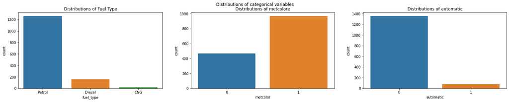

```python
 #Distributions of categorical variables
fig, axes = plt.subplots(nrows=1, ncols=num_categorical_variables, figsize=(25,4),)
fig.suptitle('Distributions of categorical variables')

sns.countplot(ax=axes[0], x="fuel_type", data = df)
axes[0].set_title("Distributions of Fuel Type")

sns.countplot(ax=axes[1], x="metcolor", data = df)
axes[1].set_title("Distributions of metcolore")

sns.countplot(ax=axes[2], x="automatic", data = df)
axes[2].set_title("Distributions of automatic")
plt.show()
```

```python
def freq(df, column):
    freq = pd.DataFrame(df.groupby([str(column)], as_index=False)[str(column)].count())
    freq['%'] = [round((i / sum(freq[column])),5) * 100 for i in freq[column]]
    print(freq)
```

```python
freq(df, "fuel_type")
print("------------")
freq(df, "metcolor")
print("------------")
freq(df, "automatic")
```

```
   fuel_type       %
0         17   1.184
1        159  11.072
2       1260  87.744
------------
   metcolor       %
0       467  32.521
1       969  67.479
------------
   automatic       %
0       1356  94.429
1         80   5.571
```

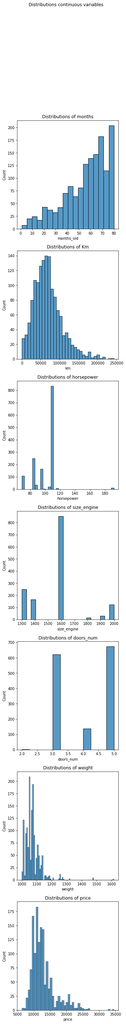

```python
#Distributions continuous variables
fig, axes = plt.subplots(nrows=num_continuous_variables, ncols=1, figsize=(5,45))
fig.suptitle('Distributions continuous variables')

sns.histplot(ax=axes[0], data=df, x="months_old")
axes[0].set_title("Distributions of months")

sns.histplot(ax=axes[1], data=df, x="km")
axes[1].set_title("Distributions of Km")

sns.histplot(ax=axes[2], data=df, x="horsepower")
axes[2].set_title("Distributions of horsepower")

sns.histplot(ax=axes[3], data=df, x="size_engine")
axes[3].set_title("Distributions of size_engine")

sns.histplot(ax=axes[4], data=df, x="doors_num")
axes[4].set_title("Distributions of doors_num")

sns.histplot(ax=axes[5], data=df, x="weight")
axes[5].set_title("Distributions of weight")

sns.histplot(ax=axes[6], data=df, x="price")
axes[6].set_title("Distributions of price")
plt.show()
```

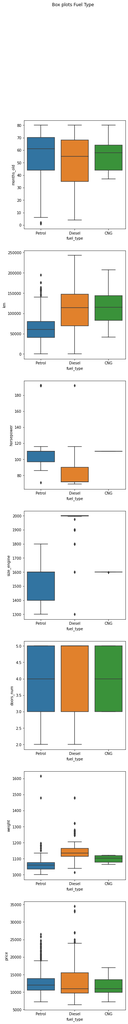

```python
fig, axes = plt.subplots(nrows=num_continuous_variables, ncols=1, figsize=(5,45))
fig.suptitle('Box plots Fuel Type')

sns.boxplot(ax=axes[0],x="fuel_type", y="months_old", data=df)
sns.boxplot(ax=axes[1],x="fuel_type", y="km", data=df)
sns.boxplot(ax=axes[2],x="fuel_type", y="horsepower", data=df)
sns.boxplot(ax=axes[3],x="fuel_type", y="size_engine", data=df)
sns.boxplot(ax=axes[4],x="fuel_type", y="doors_num", data=df)
sns.boxplot(ax=axes[5],x="fuel_type", y="weight", data=df)
sns.boxplot(ax=axes[6],x="fuel_type", y="price", data=df)

plt.show()
```

Los autos diesel tienen una mediana superio en peso en comparación a las otras clases

```python
df.groupby("automatic").describe().T
```

|  | automatic | 0 | 1 |
| --- | --- | --- | --- |
| months_old | count | 1356.000000 | 80.000000 |
|  | mean | 55.865044 | 58.375000 |
|  | std | 18.541711 | 19.096938 |
|  | min | 1.000000 | 11.000000 |
|  | 25% | 44.000000 | 46.500000 |
|  | 50% | 61.000000 | 65.000000 |
|  | 75% | 70.000000 | 73.250000 |
|  | max | 80.000000 | 80.000000 |
| km | count | 1356.000000 | 80.000000 |
|  | mean | 69278.695428 | 55898.125000 |
|  | std | 37892.516020 | 27460.141650 |
|  | min | 1.000000 | 5278.000000 |
|  | 25% | 43426.750000 | 36000.000000 |
|  | 50% | 64000.000000 | 56811.000000 |
|  | 75% | 88485.000000 | 72156.500000 |
|  | max | 243000.000000 | 143560.000000 |
| horsepower | count | 1356.000000 | 80.000000 |
|  | mean | 101.454277 | 102.312500 |
|  | std | 15.205752 | 10.499661 |
|  | min | 69.000000 | 86.000000 |
|  | 25% | 90.000000 | 86.000000 |
|  | 50% | 110.000000 | 107.000000 |
|  | 75% | 110.000000 | 110.000000 |
|  | max | 192.000000 | 110.000000 |
| metcolor | count | 1356.000000 | 80.000000 |
|  | mean | 0.676991 | 0.637500 |
|  | std | 0.467799 | 0.483755 |
|  | min | 0.000000 | 0.000000 |
|  | 25% | 0.000000 | 0.000000 |
|  | 50% | 1.000000 | 1.000000 |
|  | 75% | 1.000000 | 1.000000 |
|  | max | 1.000000 | 1.000000 |
| size_engine | count | 1356.000000 | 80.000000 |
|  | mean | 1570.494838 | 1513.425000 |
|  | std | 189.382007 | 136.443040 |
|  | min | 1300.000000 | 1300.000000 |
|  | 25% | 1400.000000 | 1300.000000 |
|  | 50% | 1600.000000 | 1600.000000 |
|  | 75% | 1600.000000 | 1600.000000 |
|  | max | 2000.000000 | 1600.000000 |
| doors_num | count | 1356.000000 | 80.000000 |
|  | mean | 4.039823 | 3.925000 |
|  | std | 0.955022 | 0.910904 |
|  | min | 2.000000 | 3.000000 |
|  | 25% | 3.000000 | 3.000000 |
|  | 50% | 4.000000 | 4.000000 |
|  | 75% | 5.000000 | 5.000000 |
|  | max | 5.000000 | 5.000000 |
| weight | count | 1356.000000 | 80.000000 |
|  | mean | 1071.915929 | 1084.862500 |
|  | std | 53.330304 | 40.929004 |
|  | min | 1000.000000 | 1015.000000 |
|  | 25% | 1035.000000 | 1063.750000 |
|  | 50% | 1065.000000 | 1075.000000 |
|  | 75% | 1085.000000 | 1105.000000 |
|  | max | 1615.000000 | 1180.000000 |
| price | count | 1356.000000 | 80.000000 |
|  | mean | 12701.691740 | 13224.625000 |
|  | std | 3625.620064 | 3636.914708 |
|  | min | 6350.000000 | 8500.000000 |
|  | 25% | 10437.500000 | 10950.000000 |
|  | 50% | 11900.000000 | 11950.000000 |
|  | 75% | 13950.000000 | 13950.000000 |
|  | max | 34500.000000 | 22950.000000 |

```python
#Los autos con Petrol tienen un media menor de kms de uso en comparación a los otros grupos.

df.groupby("fuel_type").describe().T
```

|  | fuel_type | CNG | Diesel | Petrol |
| --- | --- | --- | --- | --- |
| months_old | count | 17.000000 | 159.000000 | 1260.000000 |
|  | mean | 56.352941 | 50.861635 | 56.649206 |
|  | std | 13.332016 | 20.596017 | 18.276209 |
|  | min | 37.000000 | 4.000000 | 1.000000 |
|  | 25% | 44.000000 | 35.000000 | 44.000000 |
|  | 50% | 58.000000 | 55.000000 | 61.000000 |
|  | 75% | 64.000000 | 68.000000 | 70.250000 |
|  | max | 80.000000 | 80.000000 | 80.000000 |
| km | count | 17.000000 | 159.000000 | 1260.000000 |
|  | mean | 117865.588235 | 110636.603774 | 62554.623810 |
|  | std | 45070.154063 | 54595.966099 | 30182.658618 |
|  | min | 41499.000000 | 1.000000 | 1.000000 |
|  | 25% | 82743.000000 | 69720.000000 | 40297.250000 |
|  | 50% | 115191.000000 | 114383.000000 | 60716.000000 |
|  | 75% | 144000.000000 | 146970.000000 | 80474.000000 |
|  | max | 207114.000000 | 243000.000000 | 194545.000000 |
| horsepower | count | 17.000000 | 159.000000 | 1260.000000 |
|  | mean | 110.000000 | 79.691824 | 104.139683 |
|  | std | 0.000000 | 15.884851 | 12.495127 |
|  | min | 110.000000 | 69.000000 | 71.000000 |
|  | 25% | 110.000000 | 72.000000 | 97.000000 |
|  | 50% | 110.000000 | 72.000000 | 110.000000 |
|  | 75% | 110.000000 | 90.000000 | 110.000000 |
|  | max | 110.000000 | 192.000000 | 192.000000 |
| metcolor | count | 17.000000 | 159.000000 | 1260.000000 |
|  | mean | 0.764706 | 0.660377 | 0.675397 |
|  | std | 0.437237 | 0.475077 | 0.468412 |
|  | min | 0.000000 | 0.000000 | 0.000000 |
|  | 25% | 1.000000 | 0.000000 | 0.000000 |
|  | 50% | 1.000000 | 1.000000 | 1.000000 |
|  | 75% | 1.000000 | 1.000000 | 1.000000 |
|  | max | 1.000000 | 1.000000 | 1.000000 |
| automatic | count | 17.000000 | 159.000000 | 1260.000000 |
|  | mean | 0.058824 | 0.006289 | 0.061905 |
|  | std | 0.242536 | 0.079305 | 0.241078 |
|  | min | 0.000000 | 0.000000 | 0.000000 |
|  | 25% | 0.000000 | 0.000000 | 0.000000 |
|  | 50% | 0.000000 | 0.000000 | 0.000000 |
|  | 75% | 0.000000 | 0.000000 | 0.000000 |
|  | max | 1.000000 | 1.000000 | 1.000000 |
| size_engine | count | 17.000000 | 159.000000 | 1260.000000 |
|  | mean | 1599.882353 | 1966.446541 | 1516.509524 |
|  | std | 0.485071 | 83.122119 | 127.985903 |
|  | min | 1598.000000 | 1300.000000 | 1300.000000 |
|  | 25% | 1600.000000 | 1997.500000 | 1400.000000 |
|  | 50% | 1600.000000 | 2000.000000 | 1600.000000 |
|  | 75% | 1600.000000 | 2000.000000 | 1600.000000 |
|  | max | 1600.000000 | 2000.000000 | 1800.000000 |
| doors_num | count | 17.000000 | 159.000000 | 1260.000000 |
|  | mean | 4.117647 | 4.088050 | 4.025397 |
|  | std | 0.927520 | 0.963798 | 0.952063 |
|  | min | 3.000000 | 2.000000 | 2.000000 |
|  | 25% | 3.000000 | 3.000000 | 3.000000 |
|  | 50% | 4.000000 | 5.000000 | 4.000000 |
|  | 75% | 5.000000 | 5.000000 | 5.000000 |
|  | max | 5.000000 | 5.000000 | 5.000000 |
| weight | count | 17.000000 | 159.000000 | 1260.000000 |
|  | mean | 1097.823529 | 1156.396226 | 1061.727778 |
|  | std | 20.570717 | 72.812141 | 38.623471 |
|  | min | 1065.000000 | 1015.000000 | 1000.000000 |
|  | 25% | 1079.000000 | 1115.000000 | 1035.000000 |
|  | 50% | 1103.000000 | 1135.000000 | 1060.000000 |
|  | 75% | 1119.000000 | 1165.000000 | 1075.000000 |
|  | max | 1121.000000 | 1480.000000 | 1615.000000 |
| price | count | 17.000000 | 159.000000 | 1260.000000 |
|  | mean | 11421.176471 | 13323.937107 | 12673.649206 |
|  | std | 2492.124802 | 5547.499763 | 3313.899412 |
|  | min | 7250.000000 | 6350.000000 | 7250.000000 |
|  | 25% | 9950.000000 | 9750.000000 | 10500.000000 |
|  | 50% | 10950.000000 | 10950.000000 | 11940.000000 |
|  | 75% | 13500.000000 | 15500.000000 | 13900.000000 |
|  | max | 16950.000000 | 34500.000000 | 26500.000000 |

```python
df.groupby("metcolor").describe().T
#Los autos de transmisión automática tienen un promedio de precio ligeramente mayor,
#dicha diferencia debe ser comprobada en un contraste de Hipótesis
```

|  | metcolor | 0 | 1 |
| --- | --- | --- | --- |
| months_old | count | 467.000000 | 969.000000 |
|  | mean | 58.843683 | 54.636739 |
|  | std | 16.599782 | 19.315351 |
|  | min | 4.000000 | 1.000000 |
|  | 25% | 51.000000 | 41.000000 |
|  | 50% | 62.000000 | 60.000000 |
|  | 75% | 71.000000 | 69.000000 |
|  | max | 80.000000 | 80.000000 |
| km | count | 467.000000 | 969.000000 |
|  | mean | 72881.062099 | 66437.879257 |
|  | std | 40353.791790 | 35887.979869 |
|  | min | 1.000000 | 1.000000 |
|  | 25% | 45000.000000 | 41339.000000 |
|  | 50% | 64383.000000 | 62377.000000 |
|  | 75% | 90463.500000 | 84988.000000 |
|  | max | 243000.000000 | 217764.000000 |
| horsepower | count | 467.000000 | 969.000000 |
|  | mean | 100.235546 | 102.112487 |
|  | std | 16.418879 | 14.205063 |
|  | min | 69.000000 | 69.000000 |
|  | 25% | 86.000000 | 97.000000 |
|  | 50% | 110.000000 | 110.000000 |
|  | 75% | 110.000000 | 110.000000 |
|  | max | 192.000000 | 192.000000 |
| automatic | count | 467.000000 | 969.000000 |
|  | mean | 0.062099 | 0.052632 |
|  | std | 0.241593 | 0.223412 |
|  | min | 0.000000 | 0.000000 |
|  | 25% | 0.000000 | 0.000000 |
|  | 50% | 0.000000 | 0.000000 |
|  | 75% | 0.000000 | 0.000000 |
|  | max | 1.000000 | 1.000000 |
| size_engine | count | 467.000000 | 969.000000 |
|  | mean | 1557.415418 | 1572.086687 |
|  | std | 197.440301 | 182.047636 |
|  | min | 1300.000000 | 1300.000000 |
|  | 25% | 1400.000000 | 1400.000000 |
|  | 50% | 1600.000000 | 1600.000000 |
|  | 75% | 1600.000000 | 1600.000000 |
|  | max | 2000.000000 | 2000.000000 |
| doors_num | count | 467.000000 | 969.000000 |
|  | mean | 3.916488 | 4.089783 |
|  | std | 0.958073 | 0.945405 |
|  | min | 2.000000 | 2.000000 |
|  | 25% | 3.000000 | 3.000000 |
|  | 50% | 4.000000 | 4.000000 |
|  | 75% | 5.000000 | 5.000000 |
|  | max | 5.000000 | 5.000000 |
| weight | count | 467.000000 | 969.000000 |
|  | mean | 1068.336188 | 1074.710010 |
|  | std | 50.910007 | 53.572685 |
|  | min | 1000.000000 | 1000.000000 |
|  | 25% | 1035.000000 | 1045.000000 |
|  | 50% | 1060.000000 | 1070.000000 |
|  | 75% | 1085.000000 | 1090.000000 |
|  | max | 1480.000000 | 1615.000000 |
| price | count | 467.000000 | 969.000000 |
|  | mean | 12162.047109 | 13004.941176 |
|  | std | 3200.346464 | 3786.731865 |
|  | min | 6350.000000 | 6400.000000 |
|  | 25% | 10250.000000 | 10500.000000 |
|  | 50% | 11750.000000 | 11950.000000 |
|  | 75% | 12950.000000 | 14450.000000 |
|  | max | 34500.000000 | 33275.000000 |

- **Correlaciones**

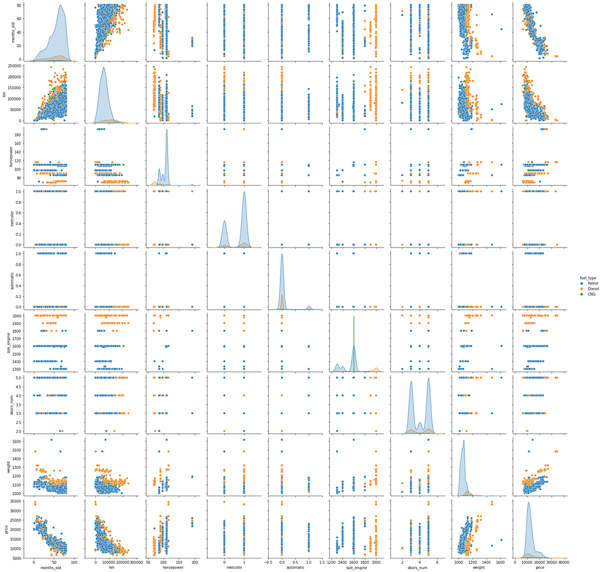

```python
sns.pairplot(df, hue="fuel_type")
plt.show()
```

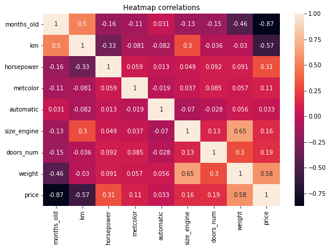

```python
#All variables correlations
f, ax = plt.subplots(figsize=(9, 6))
sns.heatmap(df.corr(), annot=True, ax=ax).set(title='Heatmap correlations')
plt.show()
```

```python
#Features correlating with Price
df_corr = pd.DataFrame(df.corr()["price"]).sort_values(by="price")
df_corr["abs"] = [abs(i) for i in df_corr["price"]]
df_corr = df_corr.sort_values(by="abs", ascending=False)
df_corr = pd.DataFrame(df_corr["price"])
df_corr[1:]
```

|  | price |
| --- | --- |
| months_old | -0.873452 |
| weight | 0.578452 |
| km | -0.569960 |
| horsepower | 0.314990 |
| doors_num | 0.185326 |
| size_engine | 0.162985 |
| metcolor | 0.108905 |
| automatic | 0.033081 |

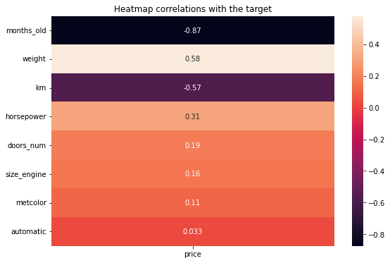

```python
f, ax = plt.subplots(figsize=(9, 6))
sns.heatmap(df_corr[1:], annot=True, ax=ax).set(title='Heatmap correlations with the target')
plt.show()
```

- **Comentarios resultado exploración**

### Comments

**Con respecto al dataset**

- El dataset se encuentra compuesto por 10 campos y 1436 registros.
- Se tienen 3 campos categóricos y 7 campos con variables continuas.
- No se presentan valores nulos o perdidos.

**Variables categóricas**

- Fuel type tiene 3 niveles Petrol, Diesel y CNG.
- Metcolor y automatic son binarias.
- La proporción de registros con CNG o autos con transmisión automática es muy baja.

**Con respecto a las distribuciones de las variables continuas**

- El número meses de los coches presenta una distribución sesgada hacia la derecha, es decir hay una mayor cantidad de registros con muchos meses.
- El número de km se encuentra sesgado ligeramente hacia la izquierda. La distribución es cercana a la normal.
- La mayoría de todos los registros tienen valores entre 100 y 120 de caballos de fuerza.
- Caso similar al tamaño del motor con el valor 1600. La mayoría de los coches en el dataset tiene 3 o 5 puertas.
- La distribución de pesos está sesgada a la izquierda al igual que los precios, esta última mucho más cercana a la normal.

**Comparando las distribuciones**

- Los grupos de coches según el tipo de combustible tienen una mediana similar con respecto a la antigüedad.
- Los autos de diesel y CNG tienen una mediana mayor en el número de kms.
- Los autos diesel presentan la mayor mediana de peso.
- La mediana de precios es similar en los 3 grupos.

**Correlaciones**

- Entre los features, observamos una relación moderada entre el kilometraje y la antigüedad del coche. También hay correlación moderada entre el peso y el tamaño del motor.
- Con respecto a las relaciones entre los features y el target. Hay una fuerte relación inversa entre el precio y los meses de antigüedad del coche.
- Relación moderada alta entre el peso y precio y entre el los kms y el precio.

## 2. Red neuronal artificial: Clasificación (4.5 puntos)

En este apartado entrenaremos un modelo que intente clasificar los coches según su gama de precio. Para ello crearemos una nueva variable como indicador de calidad del coche (gama baja, media o alta), siguiendo las siguientes condiciones:

- *low-end*: precio menor que 11000 euros
- *medium-end*: precio mayor o igual que 11000 euros y menor que 13000
- *high-end*: precio mayor o igual que 13000

### Pre-procesado

**Ejercicio (0.75 puntos):** Pre-procesa los datos:

- Crea una nueva variable `quality` que incluya la gama del coche, con las condiciones indicadas
- Muestra el histograma de la nueva variable `quality`
- Crea los vectores de variables dependientes (*features*) y de la variable independiente (*labels*)
- Normaliza debidamente los datos y binariza el vector de etiquetas (*labels*)
- Divide el conjunto de datos en 80% para entrenamiento y 20% para test, usando la función `train_test_split`
- Muestra las dimensiones de los conjuntos de entrenamiento y test

```python
#Create new variable: quality
df['quality'] = pd.cut(df['price'],bins=[0,10999,12999,max(df.price)] ,labels=['low-end', 'medium-end','high-end'])
df.sample(3)
```

|  | months_old | km | fuel_type | horsepower | metcolor | automatic | size_engine | doors_num | weight | price | quality |
| --- | --- | --- | --- | --- | --- | --- | --- | --- | --- | --- | --- |
| 1225 | 59 | 87654 | Petrol | 86 | 1 | 1 | 1300 | 5 | 1065 | 12995 | medium-end |
| 815 | 48 | 49417 | Petrol | 110 | 1 | 0 | 1600 | 3 | 1045 | 13450 | high-end |
| 138 | 80 | 84000 | Petrol | 110 | 0 | 0 | 1600 | 5 | 1075 | 8950 | low-end |

```python
df.groupby("quality").describe().T
```

|  | quality | low-end | medium-end | high-end |
| --- | --- | --- | --- | --- |
| months_old | count | 580.000000 | 416.000000 | 440.000000 |
|  | mean | 70.065517 | 59.656250 | 34.018182 |
|  | std | 7.886447 | 9.241583 | 14.378376 |
|  | min | 43.000000 | 33.000000 | 1.000000 |
|  | 25% | 65.000000 | 54.000000 | 22.000000 |
|  | 50% | 71.000000 | 61.000000 | 37.000000 |
|  | 75% | 77.000000 | 66.000000 | 44.000000 |
|  | max | 80.000000 | 80.000000 | 69.000000 |
| km | count | 580.000000 | 416.000000 | 440.000000 |
|  | mean | 89485.081034 | 66630.500000 | 42713.922727 |
|  | std | 38506.766601 | 27785.153614 | 25716.062220 |
|  | min | 1.000000 | 15000.000000 | 1.000000 |
|  | 25% | 63600.500000 | 47475.000000 | 25256.500000 |
|  | 50% | 82000.000000 | 62875.500000 | 39277.000000 |
|  | 75% | 106118.500000 | 80531.000000 | 57049.250000 |
|  | max | 243000.000000 | 180638.000000 | 179860.000000 |
| horsepower | count | 580.000000 | 416.000000 | 440.000000 |
|  | mean | 97.168966 | 102.420673 | 106.345455 |
|  | std | 14.593362 | 11.386886 | 16.764583 |
|  | min | 69.000000 | 69.000000 | 69.000000 |
|  | 25% | 86.000000 | 97.000000 | 97.000000 |
|  | 50% | 110.000000 | 110.000000 | 110.000000 |
|  | 75% | 110.000000 | 110.000000 | 110.000000 |
|  | max | 116.000000 | 110.000000 | 192.000000 |
| metcolor | count | 580.000000 | 416.000000 | 440.000000 |
|  | mean | 0.658621 | 0.603365 | 0.763636 |
|  | std | 0.474582 | 0.489788 | 0.425332 |
|  | min | 0.000000 | 0.000000 | 0.000000 |
|  | 25% | 0.000000 | 0.000000 | 1.000000 |
|  | 50% | 1.000000 | 1.000000 | 1.000000 |
|  | 75% | 1.000000 | 1.000000 | 1.000000 |
|  | max | 1.000000 | 1.000000 | 1.000000 |
| automatic | count | 580.000000 | 416.000000 | 440.000000 |
|  | mean | 0.048276 | 0.062500 | 0.059091 |
|  | std | 0.214534 | 0.242353 | 0.236063 |
|  | min | 0.000000 | 0.000000 | 0.000000 |
|  | 25% | 0.000000 | 0.000000 | 0.000000 |
|  | 50% | 0.000000 | 0.000000 | 0.000000 |
|  | 75% | 0.000000 | 0.000000 | 0.000000 |
|  | max | 1.000000 | 1.000000 | 1.000000 |
| size_engine | count | 580.000000 | 416.000000 | 440.000000 |
|  | mean | 1555.748276 | 1546.271635 | 1602.459091 |
|  | std | 216.739177 | 154.218436 | 168.337748 |
|  | min | 1300.000000 | 1300.000000 | 1300.000000 |
|  | 25% | 1300.000000 | 1400.000000 | 1600.000000 |
|  | 50% | 1600.000000 | 1600.000000 | 1600.000000 |
|  | 75% | 1600.000000 | 1600.000000 | 1600.000000 |
|  | max | 2000.000000 | 2000.000000 | 2000.000000 |
| doors_num | count | 580.000000 | 416.000000 | 440.000000 |
|  | mean | 3.834483 | 4.033654 | 4.295455 |
|  | std | 0.923789 | 0.956309 | 0.924965 |
|  | min | 2.000000 | 3.000000 | 3.000000 |
|  | 25% | 3.000000 | 3.000000 | 3.000000 |
|  | 50% | 3.000000 | 4.000000 | 5.000000 |
|  | 75% | 5.000000 | 5.000000 | 5.000000 |
|  | max | 5.000000 | 5.000000 | 5.000000 |
| weight | count | 580.000000 | 416.000000 | 440.000000 |
|  | mean | 1056.951724 | 1061.552885 | 1103.793182 |
|  | std | 37.741935 | 35.925989 | 67.791053 |
|  | min | 1000.000000 | 1000.000000 | 1025.000000 |
|  | 25% | 1035.000000 | 1035.000000 | 1075.000000 |
|  | 50% | 1050.000000 | 1062.500000 | 1080.000000 |
|  | 75% | 1075.000000 | 1075.000000 | 1120.000000 |
|  | max | 1260.000000 | 1480.000000 | 1615.000000 |
| price | count | 580.000000 | 416.000000 | 440.000000 |
|  | mean | 9950.462069 | 12122.605769 | 16970.890909 |
|  | std | 907.730787 | 562.784367 | 3609.906302 |
|  | min | 6350.000000 | 11000.000000 | 13000.000000 |
|  | 25% | 9450.000000 | 11750.000000 | 13950.000000 |
|  | 50% | 9950.000000 | 11950.000000 | 15500.000000 |
|  | 75% | 10750.000000 | 12500.000000 | 19212.500000 |
|  | max | 10995.000000 | 12995.000000 | 34500.000000 |

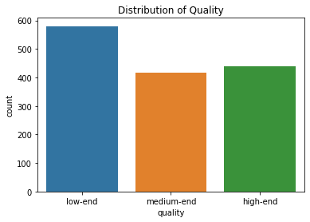

```python
#Histogram car quality
sns.countplot(x="quality", data = df).set(title='Distribution of Quality')
plt.show()
```

```python
features = ["months_old","km","horsepower","size_engine","doors_num","weight"]
```

```python
def boxplot(df, colum_X, column_Y):
    sns.boxplot(x=colum_X, y=column_Y, data=df).set(title='Box plots quality & {}'.format(column_Y))
    plt.show()
```

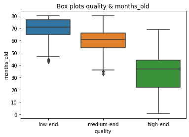

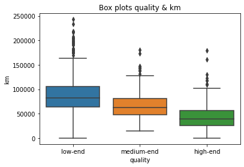

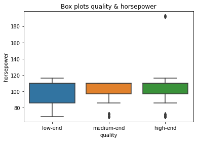

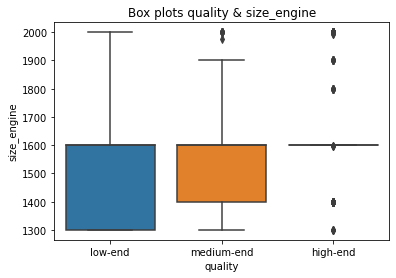

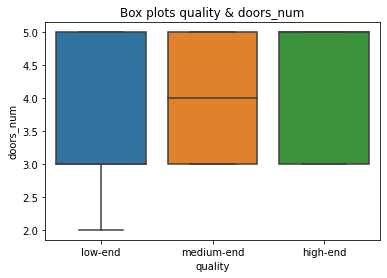

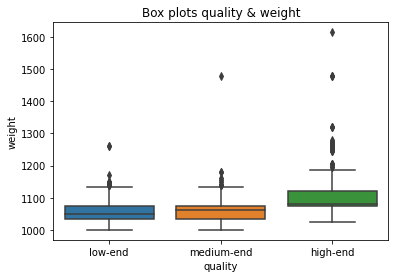

```python
for i in features:
    print("-----")
    boxplot(df, "quality", i)
```

```python
#Create features and labels vectors

df[['fuel_type_Diesel', 'fuel_type_Petrol']] = pd.get_dummies(df.fuel_type,
                                                              drop_first=True,
                                                              prefix="fuel_type",
                                                              prefix_sep="_")

features = df[['months_old', 'km', 'horsepower', 'metcolor', 'automatic',
               'size_engine', 'doors_num', 'weight', 'price',
               'fuel_type_Diesel', 'fuel_type_Petrol']]

labels = df[["quality"]]

features.sample(2)
```

|  | months_old | km | horsepower | metcolor | automatic | size_engine | doors_num | weight | price | fuel_type_Diesel | fuel_type_Petrol |
| --- | --- | --- | --- | --- | --- | --- | --- | --- | --- | --- | --- |
| 1170 | 55 | 77780 | 110 | 0 | 0 | 1600 | 3 | 1040 | 12250 | 0 | 1 |
| 370 | 52 | 47689 | 110 | 0 | 0 | 1600 | 5 | 1075 | 13895 | 0 | 1 |

```python
labels.sample(2)
```

|  | quality |
| --- | --- |
| 1381 | medium-end |
| 1272 | low-end |

```python
#Normalize the corresponding data
sc = StandardScaler()
features = sc.fit_transform(features)
```

```python
#Binarize the labels

ohe = OneHotEncoder()
labels = ohe.fit_transform(labels).toarray()
```

```python
features = df[['months_old', 'km', 'horsepower', 'metcolor', 'automatic',
               'size_engine', 'doors_num', 'weight', 'price',
               'fuel_type_Diesel', 'fuel_type_Petrol']]

sc = StandardScaler()
features = sc.fit_transform(features)


labels = df[["quality"]]
ohe = OneHotEncoder()
labels = ohe.fit_transform(labels).toarray()
```

```python
#Train-test split
train_x, test_x, train_y, test_y = train_test_split(features,
                                                    labels,
                                                    test_size=0.2,
                                                    random_state=100)
```

```python
#Shapes
print("Training set shape: \nFeatures | Labels \n{} | {}".format(train_x.shape, train_y.shape))
print('---------')
print("Test set shape: \nFeatures | Labels \n{} | {}".format(test_x.shape, test_y.shape))
```

```
Training set shape:
Features | Labels
(1148, 11) | (1148, 3)
---------
Test set shape:
Features | Labels
(288, 11) | (288, 3)
```

```python
#Number of classes
len(set(df["quality"]))
```

```
3
```

### Modelo base

Empezaremos diseñando un modelo base con 4 capas ocultas.

Nota: Para el ajuste del modelo usaremos los datos de test como conjunto de validación.

**Ejercicio (1.25 puntos):** Implementa el modelo de red neuronal artificial:

- Diseña la arquitectura para el modelo de clasificación con la función de activación adecuada para la capa de salida y con las siguientes características:
- 4 capas ocultas con 64, 32, 10, 8 neuronas sucesivamente
- Función de activación de las capas intermedias: ReLU
- Compila el modelo con la función de pérdida más adecuada, el optimizador Adam, una velocidad de aprendizaje de 0.1, y la métrica Accuracy.
- Ajusta el modelo con 20 épocas y un tamaño del batch de 64
- Muestra las gráficas de accuracy y loss. En cada gráfica debe visualizarse la curva de entrenamiento y la de validación

```python
in_dims = train_x.shape[1]
out_dims = labels.shape[1]
```

```python
#Create ANN model
model = Sequential()
model.add(Dense(64, input_dim=in_dims, activation='relu'))
model.add(Dense(32, activation='relu'))
model.add(Dense(10, activation='relu'))
model.add(Dense(8, activation='relu'))
model.add(Dense(out_dims,activation='softmax'))
```

```python
#Compile
model.compile(loss='categorical_crossentropy', optimizer=Adam(learning_rate=0.1), metrics=['accuracy'])
```

```python
#Fit
history = model.fit(train_x, train_y,
                    validation_data=(test_x, test_y),
                    epochs=20,
                    batch_size=64)
```

```python
model.summary()
```

```
Model: "sequential"
_________________________________________________________________
 Layer (type)                Output Shape              Param #
=================================================================
 dense (Dense)               (None, 64)                768

 dense_1 (Dense)             (None, 32)                2080

 dense_2 (Dense)             (None, 10)                330

 dense_3 (Dense)             (None, 8)                 88

 dense_4 (Dense)             (None, 3)                 27

=================================================================
Total params: 3,293
Trainable params: 3,293
Non-trainable params: 0
_________________________________________________________________
```

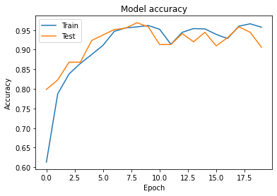

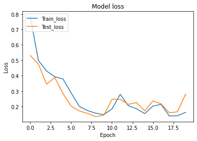

```python
#Plots
import matplotlib.pyplot as plt
def acc_plot(history):
    plt.plot(history.history['accuracy'])
    plt.plot(history.history['val_accuracy'])
    plt.title('Model accuracy')
    plt.ylabel('Accuracy')
    plt.xlabel('Epoch')
    plt.legend(['Train', 'Test'], loc='upper left')
    plt.show()

def loss_plot(history):
    plt.plot(history.history['loss'])
    plt.plot(history.history['val_loss'])
    plt.title('Model loss')
    plt.ylabel('Loss')
    plt.xlabel('Epoch')
    plt.legend(['Train_loss', 'Test_loss'], loc='upper left')
    plt.show()

acc_plot(history)
loss_plot(history)
```

A partir de las 7 epoch se llega al techo del accuracy para test y train

### Influencia velocidad aprendizaje y optimizador

Una vez tenemos el modelo base, analizaremos la influencia que pueden tener la velocidad de aprendizaje y el tipo de optimizador en la mejora del rendimiento.

**Ejercicio (1.5 puntos):** Implementa una función para entrenar la arquitectura del ejercicio anterior para 4 optimizadores diferentes: Adam, SGD, Adadelta, Adagrad, y 4 velocidades de aprendizaje: 0.001, 0.01, 0.05, 0.1. Entrena los modelos, y representa dos gráficas:

- Tiempo de entrenamiento vs Velocidad de aprendizaje
- *Accuracy* vs Velocidad de aprendizaje

Cada gráfica debe incluir la evolución obtenida por los cuatro optimizadores para poderlos comparar mejor. ----------------------------------------------------------------------------------------------------------- **Importante**: para la entrega de la PEC, fijar el parámetro `verbose = 0` en el entrenamiento de los modelos. La solución únicamente debe mostrar las gráficas resultantes.

```python
#Function to compute several models changing Optimizers and learning rate

def runModels(opt, lrt, in_dims):
    model = Sequential()
    model.add(Dense(64, input_dim=in_dims, activation='relu'))
    model.add(Dense(32, activation='relu'))
    model.add(Dense(10, activation='relu'))
    model.add(Dense(8, activation='relu'))
    model.add(Dense(3,activation='softmax'))
    start_time = time.time()

    #Compile
    model.compile(loss='categorical_crossentropy', optimizer=opt(learning_rate=lrt), metrics=['accuracy'])

    history = model.fit(train_x, train_y,
                        validation_data=(test_x, test_y),
                        epochs=20,
                        batch_size=64, verbose=0)
    end_time = time.time() - start_time
    accuracy = model.evaluate(test_x, test_y, verbose=0)[1]
    return history, end_time , accuracy
```

```python
#Compute models
in_dims = train_x.shape[1]

lr = [0.001, 0.01, 0.05, 0.1]
models = [Adam, SGD, Adadelta, Adagrad]
models_df = []
histories = []
accuracies = []
times = []
rates = []

import time
start_time = time.time()


for e in models:
    for i in lr:
        print("Training {} with {} of learning rate".format(e,i))

        models_df.append(str(e))
        rates.append(str(i))
        history, end_time , accuracy = runModels(e,i,in_dims)
        histories.append(history)
        accuracies.append(accuracy)
        times.append(end_time)


print("--- %s seconds ---" % (time.time() - start_time))
```

```
Training <class 'keras.optimizer_v2.adam.Adam'> with 0.001 of learning rate
Training <class 'keras.optimizer_v2.adam.Adam'> with 0.01 of learning rate
Training <class 'keras.optimizer_v2.adam.Adam'> with 0.05 of learning rate
Training <class 'keras.optimizer_v2.adam.Adam'> with 0.1 of learning rate
Training <class 'keras.optimizer_v2.gradient_descent.SGD'> with 0.001 of learning rate
Training <class 'keras.optimizer_v2.gradient_descent.SGD'> with 0.01 of learning rate
Training <class 'keras.optimizer_v2.gradient_descent.SGD'> with 0.05 of learning rate
Training <class 'keras.optimizer_v2.gradient_descent.SGD'> with 0.1 of learning rate
Training <class 'keras.optimizer_v2.adadelta.Adadelta'> with 0.001 of learning rate
Training <class 'keras.optimizer_v2.adadelta.Adadelta'> with 0.01 of learning rate
Training <class 'keras.optimizer_v2.adadelta.Adadelta'> with 0.05 of learning rate
Training <class 'keras.optimizer_v2.adadelta.Adadelta'> with 0.1 of learning rate
Training <class 'keras.optimizer_v2.adagrad.Adagrad'> with 0.001 of learning rate
Training <class 'keras.optimizer_v2.adagrad.Adagrad'> with 0.01 of learning rate
Training <class 'keras.optimizer_v2.adagrad.Adagrad'> with 0.05 of learning rate
Training <class 'keras.optimizer_v2.adagrad.Adagrad'> with 0.1 of learning rate
--- 35.33710527420044 seconds ---
```

```python
modelos = pd.DataFrame(list(zip(models_df,accuracies,times,rates)), columns =["Model", "Accuracy", "Time", "Learning Rate"])
modelos
```

|  | Model | Accuracy | Time | Learning Rate |
| --- | --- | --- | --- | --- |
| 0 | <class 'keras.optimizer_v2.adam.Adam'> | 0.965278 | 1.878133 | 0.001 |
| 1 | <class 'keras.optimizer_v2.adam.Adam'> | 0.982639 | 3.053371 | 0.01 |
| 2 | <class 'keras.optimizer_v2.adam.Adam'> | 0.951389 | 3.040306 | 0.05 |
| 3 | <class 'keras.optimizer_v2.adam.Adam'> | 0.951389 | 1.939467 | 0.1 |
| 4 | <class 'keras.optimizer_v2.gradient_descent.SGD'> | 0.461806 | 1.718610 | 0.001 |
| 5 | <class 'keras.optimizer_v2.gradient_descent.SGD'> | 0.750000 | 1.637419 | 0.01 |
| 6 | <class 'keras.optimizer_v2.gradient_descent.SGD'> | 0.923611 | 1.663666 | 0.05 |
| 7 | <class 'keras.optimizer_v2.gradient_descent.SGD'> | 0.961806 | 1.681759 | 0.1 |
| 8 | <class 'keras.optimizer_v2.adadelta.Adadelta'> | 0.451389 | 1.757152 | 0.001 |
| 9 | <class 'keras.optimizer_v2.adadelta.Adadelta'> | 0.371528 | 1.746773 | 0.01 |
| 10 | <class 'keras.optimizer_v2.adadelta.Adadelta'> | 0.548611 | 1.675514 | 0.05 |
| 11 | <class 'keras.optimizer_v2.adadelta.Adadelta'> | 0.763889 | 1.756877 | 0.1 |
| 12 | <class 'keras.optimizer_v2.adagrad.Adagrad'> | 0.670139 | 1.710213 | 0.001 |
| 13 | <class 'keras.optimizer_v2.adagrad.Adagrad'> | 0.864583 | 1.642183 | 0.01 |
| 14 | <class 'keras.optimizer_v2.adagrad.Adagrad'> | 0.972222 | 1.710450 | 0.05 |
| 15 | <class 'keras.optimizer_v2.adagrad.Adagrad'> | 0.937500 | 2.989832 | 0.1 |

```python
model_name = ["Adam","Adam","Adam","Adam",
              "SGD","SGD","SGD","SGD",
              "Adadelta","Adadelta","Adadelta","Adadelta",
              "Adagrad","Adagrad","Adagrad","Adagrad"]
modelos["model_name"] = model_name
modelos
```

|  | Model | Accuracy | Time | Learning Rate | model_name |
| --- | --- | --- | --- | --- | --- |
| 0 | <class 'keras.optimizer_v2.adam.Adam'> | 0.965278 | 1.878133 | 0.001 | Adam |
| 1 | <class 'keras.optimizer_v2.adam.Adam'> | 0.982639 | 3.053371 | 0.01 | Adam |
| 2 | <class 'keras.optimizer_v2.adam.Adam'> | 0.951389 | 3.040306 | 0.05 | Adam |
| 3 | <class 'keras.optimizer_v2.adam.Adam'> | 0.951389 | 1.939467 | 0.1 | Adam |
| 4 | <class 'keras.optimizer_v2.gradient_descent.SGD'> | 0.461806 | 1.718610 | 0.001 | SGD |
| 5 | <class 'keras.optimizer_v2.gradient_descent.SGD'> | 0.750000 | 1.637419 | 0.01 | SGD |
| 6 | <class 'keras.optimizer_v2.gradient_descent.SGD'> | 0.923611 | 1.663666 | 0.05 | SGD |
| 7 | <class 'keras.optimizer_v2.gradient_descent.SGD'> | 0.961806 | 1.681759 | 0.1 | SGD |
| 8 | <class 'keras.optimizer_v2.adadelta.Adadelta'> | 0.451389 | 1.757152 | 0.001 | Adadelta |
| 9 | <class 'keras.optimizer_v2.adadelta.Adadelta'> | 0.371528 | 1.746773 | 0.01 | Adadelta |
| 10 | <class 'keras.optimizer_v2.adadelta.Adadelta'> | 0.548611 | 1.675514 | 0.05 | Adadelta |
| 11 | <class 'keras.optimizer_v2.adadelta.Adadelta'> | 0.763889 | 1.756877 | 0.1 | Adadelta |
| 12 | <class 'keras.optimizer_v2.adagrad.Adagrad'> | 0.670139 | 1.710213 | 0.001 | Adagrad |
| 13 | <class 'keras.optimizer_v2.adagrad.Adagrad'> | 0.864583 | 1.642183 | 0.01 | Adagrad |
| 14 | <class 'keras.optimizer_v2.adagrad.Adagrad'> | 0.972222 | 1.710450 | 0.05 | Adagrad |
| 15 | <class 'keras.optimizer_v2.adagrad.Adagrad'> | 0.937500 | 2.989832 | 0.1 | Adagrad |

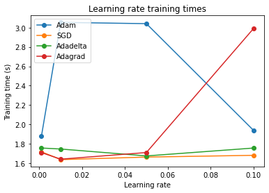

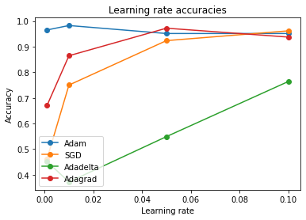

```python
#Plots

lr = [0.001, 0.01, 0.05, 0.1]
plt.plot(lr, list(modelos[modelos["model_name"] == "Adam"].iloc[:, 2]), marker="o")
plt.plot(lr, list(modelos[modelos["model_name"] == "SGD"].iloc[:, 2]), marker="o")
plt.plot(lr, list(modelos[modelos["model_name"] == "Adadelta"].iloc[:, 2]), marker="o")
plt.plot(lr, list(modelos[modelos["model_name"] == "Adagrad"].iloc[:, 2]), marker="o")
plt.title('Learning rate training times')
plt.ylabel('Training time (s)')
plt.xlabel('Learning rate')
plt.legend(['Adam', 'SGD', 'Adadelta', 'Adagrad'], loc='upper left')
plt.show()


lr = [0.001, 0.01, 0.05, 0.1]
plt.plot(lr, list(modelos[modelos["model_name"] == "Adam"].iloc[:, 1]), marker="o")
plt.plot(lr, list(modelos[modelos["model_name"] == "SGD"].iloc[:, 1]), marker="o")
plt.plot(lr, list(modelos[modelos["model_name"] == "Adadelta"].iloc[:, 1]), marker="o")
plt.plot(lr, list(modelos[modelos["model_name"] == "Adagrad"].iloc[:, 1]), marker="o")
plt.title('Learning rate accuracies')
plt.ylabel('Accuracy')
plt.xlabel('Learning rate')
plt.legend(['Adam', 'SGD', 'Adadelta', 'Adagrad'], loc='lower left')
plt.show()
```

### Elección del mejor modelo

**Ejercicio (1 punto):** Identifica el valor de la velocidad de aprendizaje y del optimizador que mejor rendimiento dan al modelo, según los resultados del ejercicio anterior:

- Justifica la elección
- Compila y entrena el modelo elegido
- Muestra las correspondientes gráficas de *Accuracy* y *Loss* de los conjuntos de entrenamiento y validación, e indica el *Accuracy* del modelo
- Muestra la matriz de confusión multi-clase con las etiquetas originales de `quality` (*low-end*, *medium-end*, *high-end*)
- Muestra la precisión, recall y F1-score resultantes para cada etiqueta
- Comenta los resultados obtenidos

```python
#Create, compile and fit ANN BEST model

bestModel = Sequential()
bestModel.add(Dense(64, input_dim=in_dims, activation='relu'))
bestModel.add(Dense(32, activation='relu'))
bestModel.add(Dense(10, activation='relu'))
bestModel.add(Dense(8, activation='relu'))
bestModel.add(Dense(out_dims,activation='softmax'))

bestModel.compile(loss='categorical_crossentropy', optimizer=Adam(learning_rate=0.001), metrics=['accuracy'])

#train_x, test_x, train_y, test_y

hist = bestModel.fit(train_x, train_y,
              validation_data=(test_x, test_y),
              epochs=20,
              batch_size=64)

pred_y = bestModel.predict(test_x)
```

```python
bestModel.summary()
```

```
Model: "sequential_17"
_________________________________________________________________
 Layer (type)                Output Shape              Param #
=================================================================
 dense_85 (Dense)            (None, 64)                768

 dense_86 (Dense)            (None, 32)                2080

 dense_87 (Dense)            (None, 10)                330

 dense_88 (Dense)            (None, 8)                 88

 dense_89 (Dense)            (None, 3)                 27

=================================================================
Total params: 3,293
Trainable params: 3,293
Non-trainable params: 0
_________________________________________________________________
```

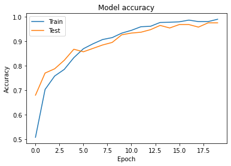

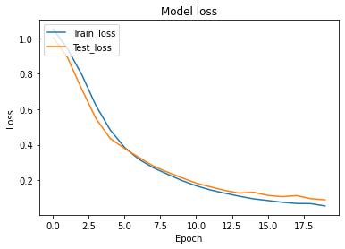

```python
#Plots
acc_plot(hist)
loss_plot(hist)
```

```python
confusion_matrix(test_y.argmax(axis=1), pred_y.argmax(axis=1))
```

```
array([[ 80,   0,   1],
       [  0, 127,   3],
       [  0,   3,  74]])
```

```python
confusion_matrix(test_y.argmax(axis=1), pred_y.argmax(axis=1), labels = [0,1,2])
```

```
array([[ 80,   0,   1],
       [  0, 127,   3],
       [  0,   3,  74]])
```

```python
cm = pd.DataFrame(
    confusion_matrix(test_y.argmax(axis=1), pred_y.argmax(axis=1)),
    index=["low-end", "medium-end", "high-end"],
    columns=["low-end", "medium-end", "high-end"]
)
cm
```

|  | low-end | medium-end | high-end |
| --- | --- | --- | --- |
| low-end | 80 | 0 | 1 |
| medium-end | 0 | 127 | 3 |
| high-end | 0 | 3 | 74 |

```python
#Accuracy
from sklearn.metrics import accuracy_score
accuracy_score(test_y.argmax(axis=1), pred_y.argmax(axis=1))
```

```
0.9756944444444444
```

El modelo alcanza un nivel de accuracy muy alto

```python
#Precision, Recall and F1-score for each label
from sklearn.metrics import classification_report

target_names = ["low-end", "medium-end", "high-end"]
print(classification_report(test_y.argmax(axis=1), pred_y.argmax(axis=1), target_names=target_names))
```

```
              precision    recall  f1-score   support

     low-end       1.00      0.99      0.99        81
  medium-end       0.98      0.98      0.98       130
    high-end       0.95      0.96      0.95        77

    accuracy                           0.98       288
   macro avg       0.98      0.98      0.98       288
weighted avg       0.98      0.98      0.98       288
```

### Comment results

- En general el modelo es bastante bueno para clasificar
- Es preciso detectando las 3 clases
- Métrica general de F1 es alta también.
- No se observan indicios de overfiting debido a que el compartamineto del accuracy es similar para el test y el train

## 3. Red neuronal artificial: Regresión (4.5 puntos)

En este apartado resolveremos un problema de regresión intentando predecir el precio de re-venta según las características de los coches. Partiremos del conjunto de datos original.

### Pre-procesado

**Ejercicio (0.5 puntos):** Pre-procesa los datos:

- Crea los vectores de variables dependientes (*features*) y de la variable independiente (*target*)
- Normaliza debidamente los datos
- Divide el conjunto de datos en 70% para entrenamiento y 30% para test, usando la función `train_test_split`
- Muestra las dimensiones de los conjuntos de entrenamiento y test

```python
df.head()
```

|  | months_old | km | fuel_type | horsepower | metcolor | automatic | size_engine | doors_num | weight | price | quality | fuel_type_Diesel | fuel_type_Petrol |
| --- | --- | --- | --- | --- | --- | --- | --- | --- | --- | --- | --- | --- | --- |
| 0 | 73 | 97494 | Petrol | 110 | 1 | 0 | 1600 | 5 | 1085 | 10950 | low-end | 0 | 1 |
| 1 | 48 | 89049 | Petrol | 97 | 1 | 0 | 1400 | 5 | 1060 | 13500 | high-end | 0 | 1 |
| 2 | 40 | 161000 | Diesel | 69 | 1 | 0 | 1900 | 3 | 1105 | 13950 | high-end | 1 | 0 |
| 3 | 37 | 38812 | Petrol | 97 | 0 | 0 | 1400 | 3 | 1025 | 13450 | high-end | 0 | 1 |
| 4 | 55 | 33230 | Petrol | 110 | 0 | 0 | 1600 | 3 | 1050 | 13500 | high-end | 0 | 1 |

```python
#Create features and target vectors
features = df[["months_old","km","horsepower","metcolor","automatic","size_engine","doors_num","weight","fuel_type_Diesel","fuel_type_Petrol"]]
target = df[["price"]]
```

```python
#Normalizing the data
sc = StandardScaler()
features = sc.fit_transform(features)
target = sc.fit_transform(target)
```

```python
#Split train-test
train_x, test_x, train_y, test_y = train_test_split(features,
                                                    target,
                                                    test_size=0.3,
                                                    random_state=100)
```

```python
#Dimensions
print("Training set shape: \nFeatures | Labels \n{} | {}".format(train_x.shape, train_y.shape))
print('---------')
print("Test set shape: \nFeatures | Labels \n{} | {}".format(test_x.shape, test_y.shape))
```

```
Training set shape:
Features | Labels
(1005, 10) | (1005, 1)
---------
Test set shape:
Features | Labels
(431, 10) | (431, 1)
```

### Modelo base

En primer lugar diseñaremos un modelo base con tres capas ocultas.

Nota: Para el ajuste del modelo usaremos los datos de test como conjunto de validación.

**Ejercicio (1 punto):** Implementa el modelo de red neuronal artificial:

- Diseña la arquitectura para el modelo de regresión con las siguientes características:
- 1 primera capa oculta completamente conectada de 128 neuronas y activación ReLU
- 2 capas ocultas de 32 y 16 neuronas y activación tangencial
- Todas las capas deben tener `kernel_initizalizer` en modo 'normal'
- Compila el modelo con la función de pérdida más adecuada y el optimizador Adam
- Ajusta el modelo con 50 épocas y un tamaño del batch de 32
- Muestra la gráfica de pérdida. En la gráfica debe visualizarse la curva de entrenamiento y la de validación

```python
#Create ANN model
model = Sequential()
model.add(Dense(128, input_dim=train_x.shape[1], activation='relu',kernel_initializer='normal'))
model.add(Dense(32, activation='tanh',kernel_initializer='normal'))
model.add(Dense(16, activation='tanh',kernel_initializer='normal',))
model.add(Dense(1))
```

```python
#Compiling the model
model.compile(loss='mean_squared_error')
```

```python
#Fit model
history = model.fit(train_x, train_y,
                        validation_data=(test_x, test_y),
                        epochs=50,
                        batch_size=32)

#pred_y = model.predict(test_x)
```

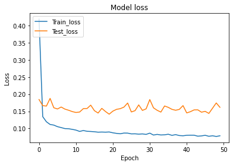

```python
#Plots
loss_plot(history)
```

### Búsqueda hiperparámetros

Una vez tenemos el modelo base nos interesa buscar la configuración de hiperparámetros que nos proporcione una mejor predicción del precio de re-venta de los coches. En este apartado haremos una búsqueda de hiperparámetros, recorriendo varios valores de número de capas, número de neuronas, tamaño del batch y épocas.

**Ejercicio (1.75 puntos):** Implementa una función que evalúe distintos modelos combinando las siguientes características:

- Tres arquitecturas diferentes con las siguientes configuraciones de número de capas ocultas (completamente conectadas) y número de neuronas en cada capa:
- [128, 64, 16]
- [16, 4]
- [4, 4]
- Tamaño del batch de 16 y 32
- Épocas de 20, 50 y 100

Como en el ejercicio anterior, la primera capa oculta tendrá siempre activación ReLU y las demás activación tangencial. El inicializador de kernel estará en modo 'normal' y usaremos el optimizador Adam. La función deberá proporcionar una tabla con los siguientes campos: arquitectura de la red seleccionada, épocas, tamaño del batch, tiempo de entrenamiento, y raíz del error cuadrático medio (RMSE) del modelo ----------------------------------------------------------------------------------------------------------- **Importante**: para la entrega de la PEC, fijar el parámetro `verbose = 0` en el entrenamiento de los modelos. La solución únicamente debe mostrar la tabla resultante.

```python
#Hiperparameter search function

def HiperparameterSearchFunction(estructura,batch,epoch,lr,train_x,test_x,train_y,test_y):
    arquitect = {"arquitectura":str(estructura),
                 "épocas": epoch,
                 "batch": batch,
                 "Learning Rate": lr
                 }


    lastValue = estructura[-1]
    model = Sequential()

    for i in range(0,len(estructura)):
      if i == 0:
        model.add(Dense(estructura[0], input_dim=train_x.shape[1], activation='relu', kernel_initializer='normal'))
      if i == lastValue:
        model.add(Dense(estructura[-1], activation='tanh', kernel_initializer='normal'))
      else:
        model.add(Dense(estructura[i],  activation='tanh',kernel_initializer='normal'))

    model.add(Dense(1))
    start_time = time.time()
    model.compile(loss="mean_absolute_error", optimizer=Adam(learning_rate=lr), metrics = [keras.metrics.RootMeanSquaredError()])
    history = model.fit(train_x, train_y,
                        validation_data=(test_x, test_y),
                        epochs=epoch,
                        batch_size=batch,
                        verbose=0)
    end_time = time.time() - start_time
    RMSE_promedio = sum(history.history["val_root_mean_squared_error"])  / len(history.history["val_root_mean_squared_error"])

    df = pd.json_normalize(arquitect)
    df["Time"] = end_time
    df["RMSE"] = RMSE_promedio
    return df
```

```python
#Compute search

features = df[["months_old","km",	"horsepower",	"metcolor",	"automatic",	"size_engine",	"doors_num",	"weight", "fuel_type_Diesel",	"fuel_type_Petrol"]]
target = df[["price"]]


sc = StandardScaler()
features = sc.fit_transform(features)
target = sc.fit_transform(target)

train_x, test_x, train_y, test_y = train_test_split(features,
                                                    target,
                                                    test_size=0.3,
                                                    random_state=100)




estructura = [[128, 64, 16], [16, 4], [4, 4]]
batchs = [16,32,64]
epochs = [20,50,100,150]
lr = [0.001, 0.01, 0.05, 0.1]


results = []

start_time = time.time()

for a in estructura:
  for e in batchs:
    for i in epochs:
      for o in lr:
        result = HiperparameterSearchFunction(a,e,i,o,train_x, test_x, train_y, test_y)
        results.append(result)




print("--- %s seconds ---" % (time.time() - start_time))
```

```
--- 1490.401686668396 seconds ---
```

```python
total = pd.concat(results)
total.head()
```

|  | arquitectura | épocas | batch | Learning Rate | Time | RMSE |
| --- | --- | --- | --- | --- | --- | --- |
| 0 | [128, 64, 16] | 20 | 16 | 0.001 | 4.195252 | 0.406333 |
| 0 | [128, 64, 16] | 20 | 16 | 0.010 | 5.587319 | 0.470431 |
| 0 | [128, 64, 16] | 20 | 16 | 0.050 | 3.983074 | 1.059919 |
| 0 | [128, 64, 16] | 20 | 16 | 0.100 | 3.938375 | 0.934010 |
| 0 | [128, 64, 16] | 50 | 16 | 0.001 | 10.717314 | 0.390340 |

```python
total = total.sort_values(by=["RMSE"])
total.head(20)
```

|  | arquitectura | épocas | batch | Learning Rate | Time | RMSE |
| --- | --- | --- | --- | --- | --- | --- |
| 0 | [128, 64, 16] | 150 | 32 | 0.001 | 14.531295 | 0.381579 |
| 0 | [128, 64, 16] | 150 | 64 | 0.001 | 10.704712 | 0.384799 |
| 0 | [128, 64, 16] | 100 | 32 | 0.001 | 9.704116 | 0.385802 |
| 0 | [4, 4] | 100 | 64 | 0.010 | 5.937893 | 0.386202 |
| 0 | [128, 64, 16] | 150 | 16 | 0.001 | 41.458765 | 0.386315 |
| 0 | [16, 4] | 100 | 32 | 0.010 | 10.664418 | 0.386971 |
| 0 | [16, 4] | 150 | 32 | 0.001 | 11.922712 | 0.388832 |
| 0 | [128, 64, 16] | 50 | 64 | 0.001 | 5.582017 | 0.389010 |
| 0 | [128, 64, 16] | 50 | 16 | 0.001 | 10.717314 | 0.390340 |
| 0 | [128, 64, 16] | 100 | 16 | 0.001 | 17.790958 | 0.390856 |
| 0 | [128, 64, 16] | 100 | 64 | 0.001 | 10.706800 | 0.391503 |
| 0 | [4, 4] | 150 | 64 | 0.050 | 10.675244 | 0.392709 |
| 0 | [128, 64, 16] | 50 | 32 | 0.001 | 5.254380 | 0.392969 |
| 0 | [16, 4] | 150 | 16 | 0.010 | 21.556996 | 0.393259 |
| 0 | [16, 4] | 150 | 32 | 0.010 | 12.487365 | 0.394882 |
| 0 | [4, 4] | 150 | 32 | 0.010 | 20.901468 | 0.394903 |
| 0 | [16, 4] | 150 | 16 | 0.001 | 41.979640 | 0.396124 |
| 0 | [4, 4] | 100 | 32 | 0.010 | 8.141929 | 0.397106 |
| 0 | [16, 4] | 50 | 32 | 0.010 | 5.564048 | 0.399428 |
| 0 | [128, 64, 16] | 150 | 64 | 0.010 | 10.708663 | 0.399988 |

```python
total[["arquitectura","RMSE"]].groupby("arquitectura").describe().T
```

|  | arquitectura | [128, 64, 16] | [16, 4] | [4, 4] |
| --- | --- | --- | --- | --- |
| RMSE | count | 48.000000 | 48.000000 | 48.000000 |
|  | mean | 0.711590 | 0.483225 | 0.449240 |
|  | std | 0.307063 | 0.108948 | 0.056521 |
|  | min | 0.381579 | 0.386971 | 0.386202 |
|  | 25% | 0.405770 | 0.409041 | 0.416765 |
|  | 50% | 0.625959 | 0.442652 | 0.433001 |
|  | 75% | 1.023370 | 0.517976 | 0.460579 |
|  | max | 1.069185 | 0.842468 | 0.704033 |

```python
total[["épocas","RMSE"]].groupby("épocas").describe().T
```

|  | épocas | 20 | 50 | 100 | 150 |
| --- | --- | --- | --- | --- | --- |
| RMSE | count | 36.000000 | 36.000000 | 36.000000 | 36.000000 |
|  | mean | 0.560095 | 0.545087 | 0.548983 | 0.537909 |
|  | std | 0.217680 | 0.215814 | 0.237274 | 0.228368 |
|  | min | 0.403039 | 0.389010 | 0.385802 | 0.381579 |
|  | 25% | 0.432812 | 0.412448 | 0.407116 | 0.399022 |
|  | 50% | 0.461782 | 0.444721 | 0.429089 | 0.420110 |
|  | 75% | 0.533791 | 0.548620 | 0.525070 | 0.532219 |
|  | max | 1.059919 | 1.062110 | 1.069185 | 1.052924 |

```python
total[["Learning Rate","RMSE"]].groupby("Learning Rate").describe().T
```

|  | Learning Rate | 0.001 | 0.010 | 0.050 | 0.100 |
| --- | --- | --- | --- | --- | --- |
| RMSE | count | 36.000000 | 36.000000 | 36.000000 | 36.000000 |
|  | mean | 0.431293 | 0.415132 | 0.631495 | 0.714153 |
|  | std | 0.059690 | 0.021031 | 0.268306 | 0.242794 |
|  | min | 0.381579 | 0.386202 | 0.392709 | 0.422303 |
|  | 25% | 0.392602 | 0.401728 | 0.434970 | 0.506050 |
|  | 50% | 0.410893 | 0.409558 | 0.462784 | 0.625063 |
|  | 75% | 0.450363 | 0.420853 | 1.008744 | 0.999586 |
|  | max | 0.704033 | 0.470431 | 1.059919 | 1.069185 |

```python
total[["batch","RMSE"]].groupby("batch").describe().T
```

|  | batch | 16 | 32 | 64 |
| --- | --- | --- | --- | --- |
| RMSE | count | 48.000000 | 48.000000 | 48.000000 |
|  | mean | 0.565916 | 0.545465 | 0.532674 |
|  | std | 0.229516 | 0.224616 | 0.217314 |
|  | min | 0.386315 | 0.381579 | 0.384799 |
|  | 25% | 0.408926 | 0.410773 | 0.409955 |
|  | 50% | 0.457150 | 0.436571 | 0.432077 |
|  | 75% | 0.571260 | 0.534969 | 0.511688 |
|  | max | 1.069185 | 1.044907 | 1.053948 |

```python
total.shape # Total de modelos probados
```

```
(144, 6)
```

```python
total["Config"] = total["arquitectura"].astype(str) + "_" + total["épocas"].astype(str) + "_" + total["batch"].astype(str) + "_" + total["Learning Rate"].astype(str)
total.head()
```

|  | arquitectura | épocas | batch | Learning Rate | Time | RMSE | Config |
| --- | --- | --- | --- | --- | --- | --- | --- |
| 0 | [128, 64, 16] | 150 | 32 | 0.001 | 14.531295 | 0.381579 | [128, 64, 16]_150_32_0.001 |
| 0 | [128, 64, 16] | 150 | 64 | 0.001 | 10.704712 | 0.384799 | [128, 64, 16]_150_64_0.001 |
| 0 | [128, 64, 16] | 100 | 32 | 0.001 | 9.704116 | 0.385802 | [128, 64, 16]_100_32_0.001 |
| 0 | [4, 4] | 100 | 64 | 0.010 | 5.937893 | 0.386202 | [4, 4]_100_64_0.01 |
| 0 | [128, 64, 16] | 150 | 16 | 0.001 | 41.458765 | 0.386315 | [128, 64, 16]_150_16_0.001 |

**Ejercicio (0.25 puntos):** Representa en un gráfico el RMSE vs la configuración de los modelos

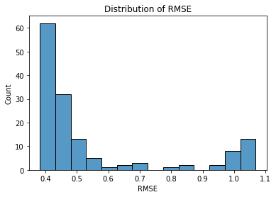

```python
sns.histplot(data=total.reset_index(drop = True), x="RMSE").set_title('Distribution of RMSE')
plt.show()
```

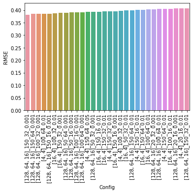

```python
sns.barplot(data=total.head(30), x="Config", y="RMSE")
plt.xticks(rotation=90)
plt.show()
```

- En general y analizando solo las estructuras, las [16,4] y [4,4] tienen en promedio un menor RSME, es decir una performance algo superior a la [128,64,16]; esto comentando sólo en terminos de la arquitectura en general y sin tomar en cuenta otros parámetros.
- El número de épocas tiene un rendimiento similar en relación a los promedio del RSME y el learning rate de 0.01 mantiene el promedio más bajo
- La distribución del score RMSE está coleada sesgada hacia el valor de 0.4 y 0.5, por lo tanto en general la mayoría de los modelos se comporta de forma similar

### Elección mejor modelo y predicción

**Ejercicio (1 punto):** Identifica la configuración que proporciona mejores resultados:

- Justifica la elección del modelo
- Compila y entrena el modelo elegido. Nota: para la entrega, presentar con verbose=0
- Muestra la correspondiente gráfica de pérdida de los conjuntos de entrenamiento y validación
- Calcula las predicciones del precio y muestra en una tabla el Precio original (`price`) y el Precio predicho (`predicted_price`) para las 10 primeras filas del conjunto de test
- Comenta los resultados obtenidos

```python
#Create, compile and fit ANN best model
model = Sequential()
model.add(Dense(128, input_dim=train_x.shape[1], activation='relu',kernel_initializer='normal'))
model.add(Dense(64, activation='tanh',kernel_initializer='normal'))
model.add(Dense(16, activation='tanh',kernel_initializer='normal',))
model.add(Dense(1))

model.compile(loss='mean_squared_error', optimizer=Adam(learning_rate=0.01), metrics = [keras.metrics.RootMeanSquaredError()])

history = model.fit(train_x, train_y,
                        validation_data=(test_x, test_y),
                        epochs=100,
                        batch_size=32,
                        verbose=0)
```

```python
model.summary()
```

```
Model: "sequential_166"
_________________________________________________________________
 Layer (type)                Output Shape              Param #
=================================================================
 dense_730 (Dense)           (None, 128)               1408

 dense_731 (Dense)           (None, 64)                8256

 dense_732 (Dense)           (None, 16)                1040

 dense_733 (Dense)           (None, 1)                 17

=================================================================
Total params: 10,721
Trainable params: 10,721
Non-trainable params: 0
_________________________________________________________________
```

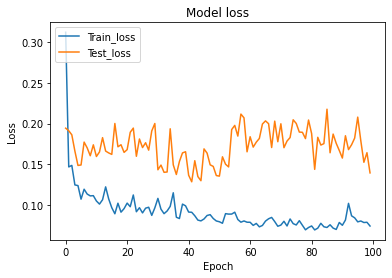

```python
#Plot
plt.plot(history.history['loss'])
plt.plot(history.history['val_loss'])
plt.title('Model loss')
plt.ylabel('Loss')
plt.xlabel('Epoch')
plt.legend(['Train_loss', 'Test_loss'], loc='upper left')
plt.show()
```

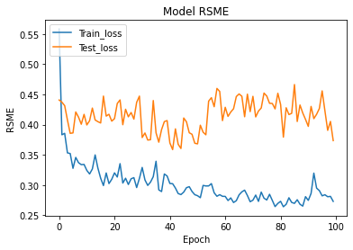

```python
plt.plot(history.history['root_mean_squared_error'])
plt.plot(history.history['val_root_mean_squared_error'])
plt.title('Model RSME')
plt.ylabel('RSME')
plt.xlabel('Epoch')
plt.legend(['Train_loss', 'Test_loss'], loc='upper left')
plt.show()
```

```python
#Generate Predictions on testing data
y_pred = model.predict(test_x)
```

```python
predicciones = pd.DataFrame(zip(list(np.reshape(y_pred, len(y_pred))),
                                list(np.reshape(test_y, len(test_y)))), columns = ["Y_Pred","Y_True"])
predicciones.head(10)
```

|  | Y_Pred | Y_True |
| --- | --- | --- |
| 0 | -0.009497 | -0.491167 |
| 1 | -0.847609 | -0.491167 |
| 2 | 3.311644 | 3.094346 |
| 3 | -0.622510 | -0.504957 |
| 4 | -0.279503 | -0.201568 |
| 5 | -0.110815 | -0.270520 |
| 6 | -0.648665 | -1.042784 |
| 7 | -0.093151 | -0.215358 |
| 8 | -0.128716 | -0.504957 |
| 9 | -0.253785 | -0.242939 |